# New York Times COVID-19 data visualization

Anton Antonov

2020-03-30

# Introduction

The purpose of this notebook is to give data locations, data ingestion code, and code for rudimentary analysis and visualization of COVID-19 data provided by New York Times, [NYT1].

The following steps are taken:

- Ingest data
  - Take COVID-19 data from The New York Times, based on reports from state and local health agencies, [NYT1].
  - Take USA counties records data (FIPS codes, geo-coordinates, populations), [WRI1].
- Merge the data.
- Make data summaries and related plots.
- Make corresponding geo-plots.
- Do “out of the box” time series forecast.
- Analyze fluctuations around time series trends.

Note that other, older repositories with COVID-19 data exist, like, [JH1, VK1].

**Remark:** The time series section is done for illustration purposes only. The forecasts there should not be taken seriously.

# Preliminary defintions

From the help of `tolower`:

```r
capwords <- function(s, strict = FALSE) {
    cap <- function(s) paste(toupper(substring(s, 1, 1)),
                  {s <- substring(s, 2); if(strict) tolower(s) else s},
                             sep = "", collapse = " " )
    sapply(strsplit(s,  split = " "), cap, USE.NAMES = !is.null(names(s)))
}
```

# Import data

## NYTimes USA states data

```r
if( !exists("dfNYDataStates") ) {
  dfNYDataStates <- read.csv( "https://raw.githubusercontent.com/nytimes/covid-19-data/master/us-states.csv",
                              colClasses = c("character", "character", "character", "integer", "integer"),
                              stringsAsFactors = FALSE )
  colnames(dfNYDataStates) <- capwords(colnames(dfNYDataStates))
}
head(dfNYDataStates)
```

[output not shown]

```r
dfNYDataStates$DateObject <- as.POSIXct(dfNYDataStates$Date)
```

```r
summary(as.data.frame(unclass(dfNYDataStates), stringsAsFactors = TRUE))
```

```
         Date                 State            Fips           Cases             Deaths        DateObject
 2020-03-28:   55   Washington   :  550   53     :  550   Min.   :      1   Min.   :    0   Min.   :2020-01-21 00:00:00
 2020-03-29:   55   Illinois     :  547   17     :  547   1st Qu.:  12981   1st Qu.:  289   1st Qu.:2020-07-07 00:00:00
 2020-03-30:   55   California   :  546   06     :  546   Median :  96374   Median : 1825   Median :2020-11-11 00:00:00
 2020-03-31:   55   Arizona      :  545   04     :  545   Mean   : 282501   Mean   : 5573   Mean   :2020-11-11 03:32:34
 2020-04-01:   55   Massachusetts:  539   25     :  539   3rd Qu.: 347656   3rd Qu.: 6660   3rd Qu.:2021-03-18 00:00:00
 2020-04-02:   55   Wisconsin    :  535   55     :  535   Max.   :3898271   Max.   :64219   Max.   :2021-07-23 00:00:00
 (Other)   :27624   (Other)      :24692   (Other):24692
```

Summary by state:

```r
by( data = as.data.frame(unclass(dfNYDataStates)), INDICES = dfNYDataStates$State, FUN = summary )
```

Alternative summary:

```r
Hmisc::describe(dfNYDataStates)
```

## NYTimes USA counties data

```r
if(!exists("dfNYDataCounties") ) {
  dfNYDataCounties <- read.csv( "https://raw.githubusercontent.com/nytimes/covid-19-data/master/us-counties.csv",
                                colClasses = c("character", "character", "character", "character", "integer", "integer"),
                                stringsAsFactors = FALSE )
  colnames(dfNYDataCounties) <- capwords(colnames(dfNYDataCounties))
}
head(dfNYDataCounties)
```

|  | Date | County | State | Fips | Cases | Deaths |
| --- | --- | --- | --- | --- | --- | --- |
| 1 | 2020-01-21 | Snohomish | Washington | 53061 | 1 | 0 |
| 2 | 2020-01-22 | Snohomish | Washington | 53061 | 1 | 0 |
| 3 | 2020-01-23 | Snohomish | Washington | 53061 | 1 | 0 |
| 4 | 2020-01-24 | Cook | Illinois | 17031 | 1 | 0 |
| 5 | 2020-01-24 | Snohomish | Washington | 53061 | 1 | 0 |
| 6 | 2020-01-25 | Orange | California | 06059 | 1 | 0 |

```r
dfNYDataCounties$DateObject <- as.POSIXct(dfNYDataCounties$Date)
```

## US county records

```r
if(!exists("dfUSACountyData")){
  dfUSACountyData <- read.csv( "https://raw.githubusercontent.com/antononcube/SystemModeling/master/Data/dfUSACountyRecords.csv",
                               colClasses = c("character", "character", "character", "character", "integer", "numeric", "numeric"),
                               stringsAsFactors = FALSE )
}
head(dfUSACountyData)
```

|  | Country | State | County | FIPS | Population | Lat | Lon |
| --- | --- | --- | --- | --- | --- | --- | --- |
| 1 | UnitedStates | SouthCarolina | AbbevilleCounty | 45001 | 24932 | 34.22256 | -82.45873 |
| 2 | UnitedStates | Louisiana | AcadiaParish | 22001 | 62577 | 30.29061 | -92.41196 |
| 3 | UnitedStates | Virginia | AccomackCounty | 51001 | 32973 | 37.76263 | -75.63210 |
| 4 | UnitedStates | Idaho | AdaCounty | 16001 | 434211 | 43.45112 | -116.24106 |
| 5 | UnitedStates | Iowa | AdairCounty | 19001 | 7228 | 41.33071 | -94.47097 |
| 6 | UnitedStates | Kentucky | AdairCounty | 21001 | 19027 | 37.10416 | -85.28056 |

```r
summary(as.data.frame(unclass(dfUSACountyData), stringsAsFactors = TRUE))
```

```
         Country          State                   County          FIPS        Population            Lat             Lon
 UnitedStates:3143   Texas   : 254   WashingtonCounty:  30   01001  :   1   Min.   :      89   Min.   :19.60   Min.   :-166.90
                     Georgia : 159   JeffersonCounty :  25   01003  :   1   1st Qu.:   10980   1st Qu.:34.70   1st Qu.: -98.23
                     Virginia: 134   FranklinCounty  :  24   01005  :   1   Median :   25690   Median :38.37   Median : -90.40
                     Kentucky: 120   JacksonCounty   :  23   01007  :   1   Mean   :  102248   Mean   :38.46   Mean   : -92.28
                     Missouri: 115   LincolnCounty   :  23   01009  :   1   3rd Qu.:   67507   3rd Qu.:41.81   3rd Qu.: -83.43
                     Kansas  : 105   MadisonCounty   :  19   01011  :   1   Max.   :10170292   Max.   :69.30   Max.   : -67.63
                     (Other) :2256   (Other)         :2999   (Other):3137
```

# Merge data

```r
dsNYDataCountiesExtended <-
  dfNYDataCounties %>%
  dplyr::inner_join( dfUSACountyData %>% dplyr::select_at( .vars = c("FIPS", "Lat", "Lon", "Population") ), by = c( "Fips" = "FIPS" ) )
dsNYDataCountiesExtended
```

| Date | County | State | Fips | Cases | Deaths | DateObject | Lat | Lon | Population |
| --- | --- | --- | --- | --- | --- | --- | --- | --- | --- |
| 2020-01-21 | Snohomish | Washington | 53061 | 1 | 0 | 2020-01-21 | 48.04735 | -121.69768 | 772501 |
| 2020-01-22 | Snohomish | Washington | 53061 | 1 | 0 | 2020-01-22 | 48.04735 | -121.69768 | 772501 |
| 2020-01-23 | Snohomish | Washington | 53061 | 1 | 0 | 2020-01-23 | 48.04735 | -121.69768 | 772501 |
| 2020-01-24 | Cook | Illinois | 17031 | 1 | 0 | 2020-01-24 | 41.83988 | -87.81683 | 5238216 |
| 2020-01-24 | Snohomish | Washington | 53061 | 1 | 0 | 2020-01-24 | 48.04735 | -121.69768 | 772501 |
| 2020-01-25 | Orange | California | 06059 | 1 | 0 | 2020-01-25 | 33.70278 | -117.76114 | 3169776 |
| 2020-01-25 | Cook | Illinois | 17031 | 1 | 0 | 2020-01-25 | 41.83988 | -87.81683 | 5238216 |
| 2020-01-25 | Snohomish | Washington | 53061 | 1 | 0 | 2020-01-25 | 48.04735 | -121.69768 | 772501 |
| 2020-01-26 | Maricopa | Arizona | 04013 | 1 | 0 | 2020-01-26 | 33.34882 | -112.49123 | 4167947 |
| 2020-01-26 | Los Angeles | California | 06037 | 1 | 0 | 2020-01-26 | 34.35875 | -118.21729 | 10170292 |

[output cut: 990 more lines]

# Basic data analysis

```r
ParetoPlotForColumns( dsNYDataCountiesExtended, c("Cases", "Deaths"), scales = "free" )
```

# Geo-histogram

## ggplot2

Note that in the plots in this sub-section we filter out Hawaii and Alaska.

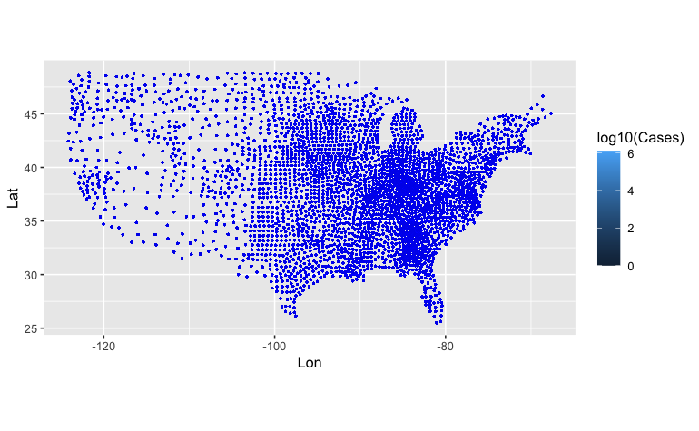

```r
ggplot2::ggplot(dsNYDataCountiesExtended[ dsNYDataCountiesExtended$Lon > -130, c("Lat", "Lon", "Cases")]) +
  ggplot2::geom_point( ggplot2::aes(x = Lon, y = Lat, fill = log10(Cases)), alpha = 0.01, size = 0.5, color = "blue" ) +
  ggplot2::coord_quickmap()
```

## Leaflet

*The most recent versions of `leaflet` RStudio are having problems with the visualization below.*

```r
cf <- colorBin( palette = "Reds", domain = log10(dsNYDataCountiesExtended$Cases), bins = 10 )
```

```r
m <-
  leaflet( dsNYDataCountiesExtended[, c("Lat", "Lon", "Cases")] ) %>%
  addTiles() %>%
  addCircleMarkers( ~Lon, ~Lat, radius = ~ log10(Cases), fillColor = ~ cf(log10(Cases)), color = ~ cf(log10(Cases)), fillOpacity = 0.8, stroke = FALSE, popup = ~Cases )
m
```

```r
dsNYDataCountiesExtended
```

| Date | County | State | Fips | Cases | Deaths | DateObject | Lat | Lon | Population |
| --- | --- | --- | --- | --- | --- | --- | --- | --- | --- |
| 2020-01-21 | Snohomish | Washington | 53061 | 1 | 0 | 2020-01-21 | 48.04735 | -121.69768 | 772501 |
| 2020-01-22 | Snohomish | Washington | 53061 | 1 | 0 | 2020-01-22 | 48.04735 | -121.69768 | 772501 |
| 2020-01-23 | Snohomish | Washington | 53061 | 1 | 0 | 2020-01-23 | 48.04735 | -121.69768 | 772501 |
| 2020-01-24 | Cook | Illinois | 17031 | 1 | 0 | 2020-01-24 | 41.83988 | -87.81683 | 5238216 |
| 2020-01-24 | Snohomish | Washington | 53061 | 1 | 0 | 2020-01-24 | 48.04735 | -121.69768 | 772501 |
| 2020-01-25 | Orange | California | 06059 | 1 | 0 | 2020-01-25 | 33.70278 | -117.76114 | 3169776 |
| 2020-01-25 | Cook | Illinois | 17031 | 1 | 0 | 2020-01-25 | 41.83988 | -87.81683 | 5238216 |
| 2020-01-25 | Snohomish | Washington | 53061 | 1 | 0 | 2020-01-25 | 48.04735 | -121.69768 | 772501 |
| 2020-01-26 | Maricopa | Arizona | 04013 | 1 | 0 | 2020-01-26 | 33.34882 | -112.49123 | 4167947 |
| 2020-01-26 | Los Angeles | California | 06037 | 1 | 0 | 2020-01-26 | 34.35875 | -118.21729 | 10170292 |

[output cut: 990 more lines]

# Heat-map plots

An alternative of the geo-visualization is to use a heat-map plot.

## Cases

Make a heat-map plot by sorting the rows of the cross-tabulation matrix (that correspond to states):

```r
matSDC <- xtabs( Cases ~ State + Date, dfNYDataStates, sparse = TRUE)
d3heatmap::d3heatmap( log10(matSDC+1), cellnote = as.matrix(matSDC), scale = "none", dendrogram = "row", colors = "Blues") #, theme = "dark")
```

[interactive chart not shown]

## Deaths

Cross-tabulate states with dates over deaths and plot:

```r
matSDD <- xtabs( Deaths ~ State + Date, dfNYDataStates, sparse = TRUE)
d3heatmap::d3heatmap( log10(matSDD+1), cellnote = as.matrix(matSDD), scale = "none", dendrogram = "row", colors = "Blues") #, theme = "dark")
```

[interactive chart not shown]

# Time series analysis

In this section we do simple “forecasting” (not a serious attempt).

Make time series data frame in long form:

```r
dfQuery <-
  dfNYDataStates %>%
  dplyr::group_by( Date, DateObject ) %>%
  dplyr::summarise_at( .vars = c("Cases", "Deaths"), .funs = sum )
dfQueryLongForm <- tidyr::pivot_longer( dfQuery, cols = c("Cases", "Deaths"), names_to = "Variable", values_to = "Value")
head(dfQueryLongForm)
```

| Date | DateObject | Variable | Value |
| --- | --- | --- | --- |
| 2020-01-21 | 2020-01-21 | Cases | 1 |
| 2020-01-21 | 2020-01-21 | Deaths | 0 |
| 2020-01-22 | 2020-01-22 | Cases | 1 |
| 2020-01-22 | 2020-01-22 | Deaths | 0 |
| 2020-01-23 | 2020-01-23 | Cases | 1 |
| 2020-01-23 | 2020-01-23 | Deaths | 0 |

Plot the time series:

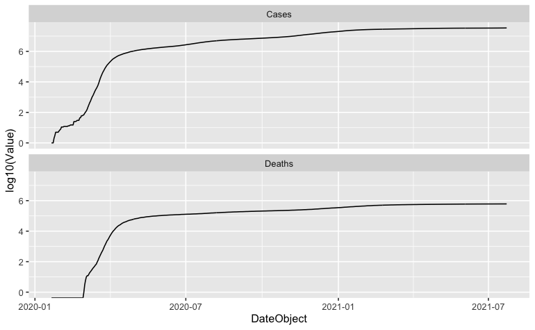

```r
ggplot(dfQueryLongForm) +
  geom_line( aes( x = DateObject, y = log10(Value) ) ) +
  facet_wrap( ~Variable, ncol = 1 )
```

## Cases

Fit using ARIMA:

```r
fit <- forecast::auto.arima( dfQuery$Cases )
fit
```

```
Series: dfQuery$Cases
ARIMA(0,2,1)

Coefficients:
          ma1
      -0.5962
s.e.   0.0335

sigma^2 estimated as 243472353:  log likelihood=-6068.38
AIC=12140.76   AICc=12140.78   BIC=12149.37
```

Plot “forecast”:

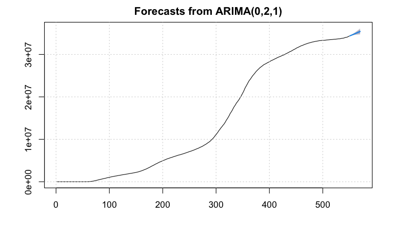

```r
plot( forecast::forecast(fit, h = 20) )
grid(nx = NULL, ny = NULL, col = "lightgray", lty = "dotted")
```

## Deaths

Fit with ARIMA:

```r
fit <- forecast::auto.arima( dfQuery$Deaths )
fit
```

```
Series: dfQuery$Deaths
ARIMA(3,2,2)

Coefficients:
         ar1      ar2      ar3      ma1     ma2
      0.9916  -0.6238  -0.1850  -1.3688  0.6476
s.e.  0.0573   0.0620   0.0536   0.0449  0.0361

sigma^2 estimated as 141203:  log likelihood=-4025.37
AIC=8062.73   AICc=8062.89   BIC=8088.57
```

Plot “forecast”:

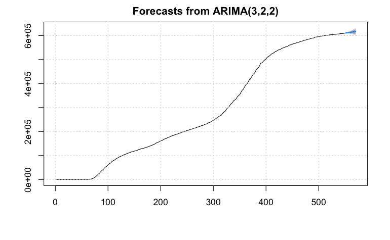

```r
plot( forecast::forecast(fit, h = 20) )
grid(nx = NULL, ny = NULL, col = "lightgray", lty = "dotted")
```

# Fluctuations

We want to see does the time series data have fluctuations around its trends and estimate the distributions of those fluctuations. (Knowing those distributions some further studies can be done.)

This can be efficiently using the software monad `QRMon`, [AAp2, AA1]. Here we load the `QRMon` package:

```r
#devtools::install_github(repo = "antononcube/QRMon-R")
library(QRMon)
```

## Fluctuations presence

Here we plot the consecutive differences of the cases and deaths:

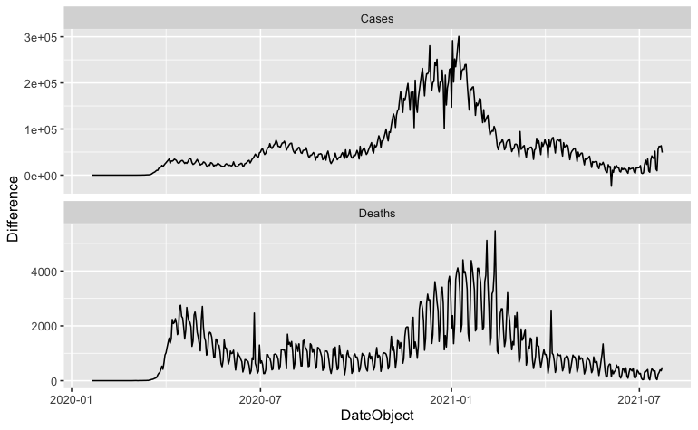

```r
dfQueryLongForm <-
  dfQueryLongForm %>%
  dplyr::group_by( Variable ) %>%
  dplyr::arrange( DateObject ) %>%
  dplyr::mutate( Difference = c(0, diff(Value) ) ) %>%
  dplyr::ungroup()
ggplot(dfQueryLongForm) +
  geom_line( aes( x = DateObject, y = Difference ) ) +
  facet_wrap( ~Variable, ncol = 1, scales = "free_y" )
```

From the plots we see that time series are not monotonically increasing, and there are non-trivial fluctuations in the data.

## Absolute and relative errors distributions

Here we take interesting part of the cases data:

```r
dfQueryLongForm2 <-
  dfQueryLongForm %>%
  dplyr::filter( difftime( DateObject, as.POSIXct("2020-05-01")) >= 0 ) %>%
  dplyr::mutate( Regressor = as.numeric(DateObject, origin = "1900-01-01") )
```

Here we specify a `QRMon` workflow that rescales the data, fits a B-spline curve to get the trend, and finds the absolute and relative errors (residuals, fluctuations) around that trend:

```r
qrObj <-
  QRMonUnit(dfQueryLongForm2 %>% dplyr::filter( Variable == "Cases") %>% dplyr::select( Regressor, Value) ) %>%
  QRMonRescale(regressorAxisQ = F, valueAxisQ = T) %>%
  QRMonEchoDataSummary %>%
  QRMonQuantileRegression( df = 16, probabilities = 0.5 )
```

```
$Dimensions
[1] 449   2

$Summary
   Regressor             Value
 Min.   :1.588e+09   Min.   :0.0000
 1st Qu.:1.598e+09   1st Qu.:0.1362
 Median :1.608e+09   Median :0.4475
 Mean   :1.608e+09   Mean   :0.4946
 3rd Qu.:1.617e+09   3rd Qu.:0.8883
 Max.   :1.627e+09   Max.   :1.0000
```

Here we plot the fit:

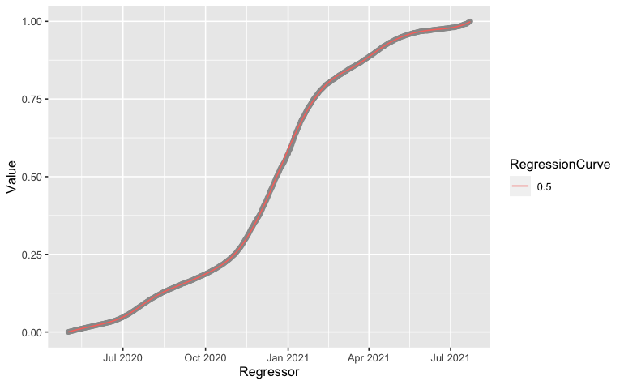

```r
qrObj <- qrObj %>% QRMonPlot(datePlotQ = T)
```

Here we plot absolute errors:

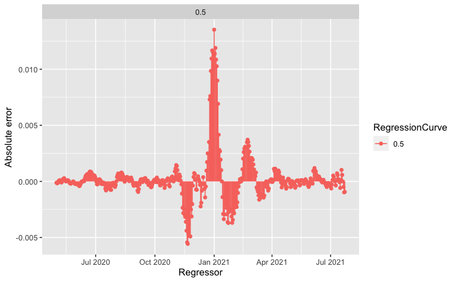

```r
qrObj <- qrObj %>% QRMonErrorsPlot(relativeErrorsQ = F, datePlotQ = T)
```

Here is the summary:

```r
summary( (qrObj %>% QRMonErrors(relativeErrorsQ = F) %>% QRMonTakeValue)[[1]]$Error )
```

```
      Min.    1st Qu.     Median       Mean    3rd Qu.       Max.
-0.0055675 -0.0003577  0.0000000  0.0001826  0.0003727  0.0135218
```

Here we plot relative errors:

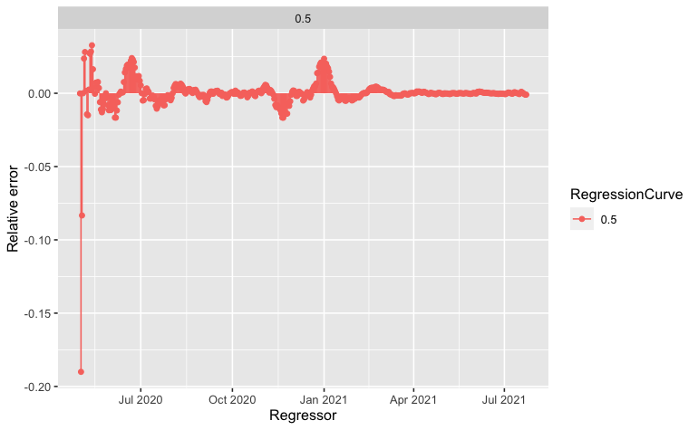

```r
qrObj <- qrObj %>% QRMonErrorsPlot(relativeErrorsQ = T, datePlotQ = T)
```

Here is the summary:

```r
summary( (qrObj %>% QRMonErrors(relativeErrorsQ = T) %>% QRMonTakeValue)[[1]]$Error )
```

```
      Min.    1st Qu.     Median       Mean    3rd Qu.       Max.
-1.900e-01 -1.541e-03  0.000e+00  2.250e-06  1.266e-03  3.275e-02
```

# Refereces

[NYT1] The New York Times, [Coronavirus (Covid-19) Data in the United States](https://github.com/nytimes/covid-19-data), (2020), GitHub.

[WRI1] Wolfram Research Inc., [USA county records](https://github.com/antononcube/SystemModeling/blob/master/Data/dfUSACountyRecords.csv), (2020), [System Modeling at GitHub](https://github.com/antononcube/SystemModeling).

[JH1] CSSE at Johns Hopkins University, COVID-19, (2020), GitHub.

[VK1] Vitaliy Kaurov, [Resources For Novel Coronavirus COVID-19](https://community.wolfram.com/groups/-/m/t/1872608), (2020), community.wolfram.com.

[AA1] Anton Antonov, [“A monad for Quantile Regression workflows”](https://mathematicaforprediction.wordpress.com/2018/08/01/a-monad-for-quantile-regression-workflows/), (2018), at [MathematicaForPrediction WordPress](https://mathematicaforprediction.wordpress.com).

[AAp1] Anton Antonov, [Heatmap plot Mathematica package](https://github.com/antononcube/MathematicaForPrediction/blob/master/Misc/HeatmapPlot.m), (2018), [MathematicaForPrediciton at GitHub](https://github.com/antononcube/MathematicaForPrediction).

[AAp2] Anton Antonov, [Monadic Quantile Regression Mathematica package](https://github.com/antononcube/MathematicaForPrediction/blob/master/MonadicProgramming/MonadicQuantileRegression.m), (2018), [MathematicaForPrediciton at GitHub](https://github.com/antononcube/MathematicaForPrediction).